## Module 3

#### Hemi-module gene counts:

361 probesets in positive hemi-module.  
344 probesets in negative hemi-module.  
Note: While the mapping of probesets to genes is generally one-to-one, some probesets map to multiple genes and some do not map to any genes (i.e., the region of the genome they match is no longer considered genic).

#### Contrast SVE:

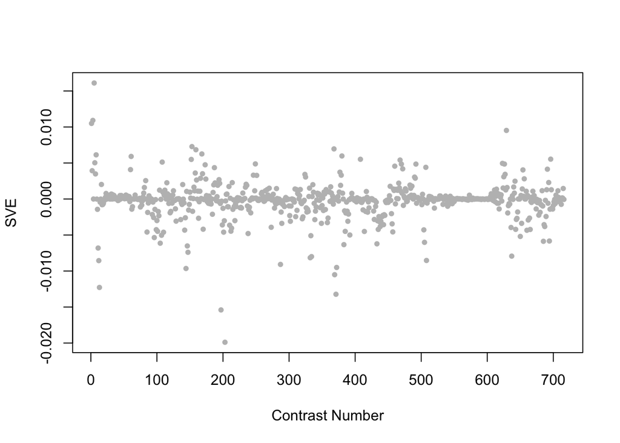

Positive SVE Contrasts:

|  | Contrast.Num | SVE | GEO.GSE | Cond.1 | Cond.2 | Mutation |
| --- | --- | --- | --- | --- | --- | --- |
| GSE9897B.s2t1.vs.s0t1 | 5 | 0.02 | GSE9897 | Complex I RNAi Mutant 2 | Wildtype (control for RNAi) | Y45G12B.1 |
| GSE9897A.s3t1.vs.s0t1 | 3 | 0.01 | GSE9897 | Complex III missense mutant | Wildtype (control for missense) | isp-1 |
| GSE9897A.s1t1.vs.s0t1 | 1 | 0.01 | GSE9897 | Complex I missense mutant | Wildtype (control for missense) | gas-1 |
| GSE19310A.s2t1.vs.s0t1 | 629 | 0.01 | GSE19310 | osm-7(n1515) at iso, rep1 | N2 at iso, rep1 | osm-7 |
| GSE47778.s5t1.vs.s3t1 | 153 | 0.01 | GSE47778 | xpa-1 0mJ/cm2; replicate 1 | daf-16; replicate 1 | xpa-1 vs. daf-16 |

Negative SVE Contrasts:

|  | Contrast.Num | SVE | GEO.GSE | Cond.1 | Cond.2 | Mutation |
| --- | --- | --- | --- | --- | --- | --- |
| GSE43952.s1t1.vs.s0t1 | 203 | -0.02 | GSE43952 | metr-1(ok521) fed Comamonas DA1877 rep 1 | N2 gravid adult fed Comamonas DA1877 rep 1 | metr-1 |
| GSE43959.s1t1.vs.s2t1 | 197 | -0.02 | GSE43959 | N2 young adult on E. coli OP50 rep 1 | N2 young adult on E. coli HT115 rep 1 |  |
| GSE35360C.s1t1.vs.s0t1 | 371 | -0.01 | GSE35360 | HFHQ 3d_0.2_rep1 | HFHQ 3d control_rep1 |  |
| GSE9682.s2t2.vs.s0t2 | 13 | -0.01 | GSE9682 | N2-Cel-TORRNAi-fed-biological rep1 | N2-controlRNAi-fed-biological rep1 | TOR |
| GSE35360B.s1t1.vs.s0t1 | 369 | -0.01 | GSE35360 | HF 3d_0.2_rep1 | HF 3d control_rep1 |  |

#### Contrast SVE, Up-Regulated Genes Only:

Calculating SVE for up-regulated and down-regulated genes separately may be more informative in many cases than projecting the up- and down- gene sets together. This is due to the fact that the weight distribution of many modules is highly skewed, indicating that only one of the hemi-modules may be biologically meaningful (i.e., a set of genes are strongly correlated buy only a few genes (or none) are strongly anti-correlated to that set.)

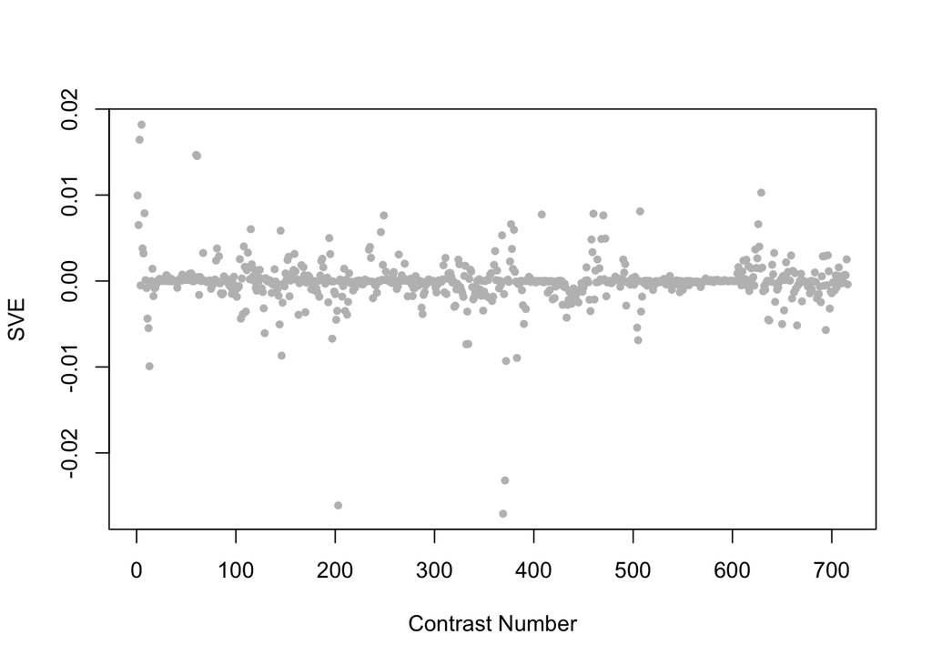

Positive SVE Contrasts:

|  | Contrast.Num | SVE | GEO.GSE | Cond.1 | Cond.2 | Mutation |
| --- | --- | --- | --- | --- | --- | --- |
| GSE9897B.s2t1.vs.s0t1 | 5 | 0.02 | GSE9897 | Complex I RNAi Mutant 2 | Wildtype (control for RNAi) | Y45G12B.1 |
| GSE9897A.s3t1.vs.s0t1 | 3 | 0.02 | GSE9897 | Complex III missense mutant | Wildtype (control for missense) | isp-1 |
| GSE9301.s3t1.vs.s1t1 | 60 | 0.01 | GSE9301 | 3-day-old TJ1090 worms without any stress (C1) | 3-day-old TJ1090 worms with oxidative stress (O1) |  |
| GSE9301.s3t1.vs.s2t1 | 61 | 0.01 | GSE9301 | 3-day-old TJ1090 worms without any stress (C1) | 3-day-old TJ1090 worms with skn-1 RNAi & oxidative stress (SO1) |  |
| GSE19310A.s2t1.vs.s0t1 | 629 | 0.01 | GSE19310 | osm-7(n1515) at iso, rep1 | N2 at iso, rep1 | osm-7 |

Negative SVE Contrasts:

|  | Contrast.Num | SVE | GEO.GSE | Cond.1 | Cond.2 | Mutation |
| --- | --- | --- | --- | --- | --- | --- |
| GSE35360B.s1t1.vs.s0t1 | 369 | -0.03 | GSE35360 | HF 3d_0.2_rep1 | HF 3d control_rep1 |  |
| GSE43952.s1t1.vs.s0t1 | 203 | -0.03 | GSE43952 | metr-1(ok521) fed Comamonas DA1877 rep 1 | N2 gravid adult fed Comamonas DA1877 rep 1 | metr-1 |
| GSE35360C.s1t1.vs.s0t1 | 371 | -0.02 | GSE35360 | HFHQ 3d_0.2_rep1 | HFHQ 3d control_rep1 |  |
| GSE9682.s2t2.vs.s0t2 | 13 | -0.01 | GSE9682 | N2-Cel-TORRNAi-fed-biological rep1 | N2-controlRNAi-fed-biological rep1 | TOR |
| GSE35360C.s2t1.vs.s0t1 | 372 | -0.01 | GSE35360 | HFHQ 3d_2.0_rep1 | HFHQ 3d control_rep1 |  |

#### Contrast SVE, Down-Regulated Genes Only:

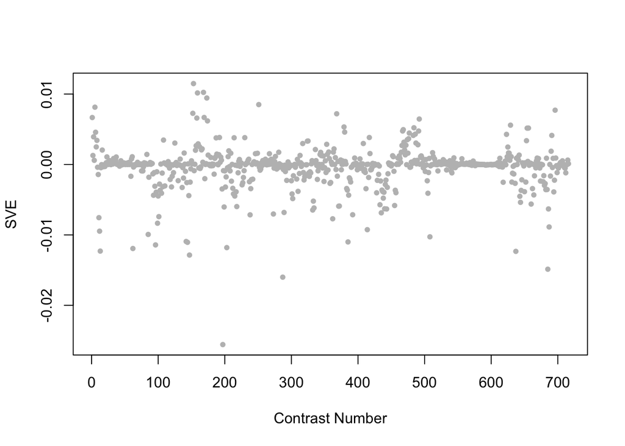

Positive SVE Contrasts:

|  | Contrast.Num | SVE | GEO.GSE | Cond.1 | Cond.2 | Mutation |
| --- | --- | --- | --- | --- | --- | --- |
| GSE47778.s5t1.vs.s3t1 | 153 | 0.01 | GSE47778 | xpa-1 0mJ/cm2; replicate 1 | daf-16; replicate 1 | xpa-1 vs. daf-16 |
| GSE47778.s1t3.vs.s3t3 | 168 | 0.01 | GSE47778 | N2; UV; replicate 1 | daf-16; UV; replicate 1 | daf-16 |
| GSE47778.s5t1.vs.s1t1 | 159 | 0.01 | GSE47778 | xpa-1 0mJ/cm2; replicate 1 | N2; replicate 1 | xpa-1 |
| GSE47778.s1t3.vs.s4t3 | 173 | 0.01 | GSE47778 | N2; UV; replicate 1 | daf-2;daf-16; UV; replicate 1 | daf-2;daf-16 |
| GSE42192.s2t1.vs.s0t1 | 251 | 0.01 | GSE42192 | C.elegans fed with CNCM I-4317 3 days rep1 | C.elegans fed with E.coli OP50 3 days rep1 |  |

Negative SVE Contrasts:

|  | Contrast.Num | SVE | GEO.GSE | Cond.1 | Cond.2 | Mutation |
| --- | --- | --- | --- | --- | --- | --- |
| GSE43959.s1t1.vs.s2t1 | 197 | -0.03 | GSE43959 | N2 young adult on E. coli OP50 rep 1 | N2 young adult on E. coli HT115 rep 1 |  |
| GSE41366C.s2t4.vs.s0t4 | 287 | -0.02 | GSE41366 | high_DDVP-continuous_expose-20h_harvest-rep1 | control-continuous_expose-14h_harvest-rep1 |  |
| GSE12298C.s3t1.vs.s0t1 | 685 | -0.01 | GSE12298 | mefloquine_high_dose-rep1 | mefloquine_control-rep1 |  |
| GSE50513.s4t1.vs.s3t1 | 147 | -0.01 | GSE50513 | zip-2 PA14 - rep 1 | zip-2 OP50 - rep 1 |  |
| GSE18132.s1t2.vs.s0t2 | 637 | -0.01 | GSE18132 | Ogt Fed L4, biological replicate 1 | WT Fed L4, biological rep1 | ogt-1 |

#### GO Term Enrichment:

This analysis tests each hemi-module for enrichment of specific GO terms. Only gene-level annotations (e.g., as would be found on the gene’s page in Wormbase) are tested - the hiearchical structure of the GO ontology is not taken into account. Negative enrichment scores indicate fewer hemi-module genes than expected by random chance were assiciated with the GO term in question.

##### Significant GO terms: Positive hemi-module

No significant annotations.

##### Significant GO terms: Negative hemi-module

No significant annotations.

#### REACTOME Pathway Enrichment:

This analysis tests each hemi-module for enrichment of REACTOME pathways (n.b., the term ‘pathway’ is used very loosely by REACTOME, and can be something as small as a single biochemical reaction or even a macromolecular complex.) This analysis was performed using an old version of REACTOME, and they have since changed their ID scheme. Thus, the links to the REACTOME database are non-functional at present (but more info for a pathway can be found by searching for the pathway definition at http://www.reactome.org) Negative enrichment scores indicate fewer hemi-module genes than expected by random chance were associated with the pathway in question.

##### Significant REACTOME pathways: Positive hemi-module

No significant annotations.

##### Significant REACTOME pathways: Negative hemi-module

No significant annotations.

#### Tissue Enrichment:

This analysis tests each hemi-module for enrichment of genes associated with specific tissues. Negative enrichment scores indicate fewer hemi-module genes than expected by random chance were assiciated with the tissue in question.

##### Significant Enriched tissues: Positive hemi-module

No significant annotations.

##### Significant Enriched tissues: Negative hemi-module

No significant annotations.

#### Promoter Word Enrichment:

This analysis tests each hemi-module for enrichment of specific promoter words. The list of promoter words tested was generated by running the MobyDick algorithm (see PMID:10944202) on the full set of *C. elegans* 2 Kbp promoters. Negative enrichment scores indicate fewer hemi-module genes than expected by random chance were associated with the word in question.

##### Significant Promoter words: Positive hemi-module

| Word | RC | Enrichment.Score | Raw.p.value | Adj.p.value |
| --- | --- | --- | --- | --- |
| TTCAAGT | ACTTGAA | 9.74 | 1.83e-10 | 9.57e-07 |
| CAATTTTCC | GGAAAATTG | 7.70 | 2.01e-08 | 1.05e-04 |
| TTATCAGT | ACTGATAA | 7.65 | 2.24e-08 | 1.17e-04 |
| ACTAATAGAGG | CCTCTATTAGT | 6.97 | 1.07e-07 | 5.59e-04 |
| GCAAGCGCGCTC | GAGCGCGCTTGC | 6.88 | 1.30e-07 | 6.81e-04 |
| GTGATAAG | CTTATCAC | 6.81 | 1.57e-07 | 8.18e-04 |
| ATCAGT | ACTGAT | 6.33 | 4.69e-07 | 2.45e-03 |
| ACTAATAGA | TCTATTAGT | 6.26 | 5.44e-07 | 2.84e-03 |
| TTATCAG | CTGATAA | 5.76 | 1.73e-06 | 9.04e-03 |
| GATCAAG | CTTGATC | 5.62 | 2.42e-06 | 1.26e-02 |
| CTTATCAC | GTGATAAG | 5.27 | 5.36e-06 | 2.80e-02 |
| AATATTT | AAATATT | 5.27 | 5.41e-06 | 2.82e-02 |
| TTTCAAG | CTTGAAA | 5.21 | 6.21e-06 | 3.24e-02 |
| ACTCTCTG | CAGAGAGT | 5.20 | 6.28e-06 | 3.27e-02 |
| TGATATCA | TGATATCA | 5.16 | 6.94e-06 | 3.62e-02 |
| AGTGATAAG | CTTATCACT | 4.99 | 1.01e-05 | 5.28e-02 |
| ACTAATAGAG | CTCTATTAGT | 4.98 | 1.05e-05 | 5.48e-02 |
| CCCCCCCCCCCC | GGGGGGGGGGGG | 4.91 | 1.22e-05 | 6.37e-02 |
| AGTACGG | CCGTACT | 4.89 | 1.27e-05 | 6.64e-02 |
| CAGAAA | TTTCTG | 4.85 | 1.41e-05 | 7.35e-02 |

##### Significant Promoter words: Negative hemi-module

| Word | RC | Enrichment.Score | Raw.p.value | Adj.p.value |
| --- | --- | --- | --- | --- |
| AAGTAC | GTACTT | 8.53 | 2.93e-09 | 1.53e-05 |
| TAAAGGT | ACCTTTA | 8.01 | 9.69e-09 | 5.06e-05 |
| ACCTACA | TGTAGGT | 7.38 | 4.18e-08 | 2.19e-04 |
| TGGCTTC | GAAGCCA | 6.76 | 1.72e-07 | 8.98e-04 |
| GGGTCC | GGACCC | 6.76 | 1.73e-07 | 9.06e-04 |
| CGGCAAACCGG | CCGGTTTGCCG | 6.75 | 1.80e-07 | 9.39e-04 |
| GGCAAACCGGC | GCCGGTTTGCC | 6.62 | 2.41e-07 | 1.26e-03 |
| TCTTATC | GATAAGA | 6.30 | 5.04e-07 | 2.63e-03 |
| GCAAACCGGCA | TGCCGGTTTGC | 6.28 | 5.22e-07 | 2.72e-03 |
| AGTATA | TATACT | 6.22 | 6.01e-07 | 3.14e-03 |
| ATAGT | ACTAT | 5.97 | 1.08e-06 | 5.64e-03 |
| TTTCTTATC | GATAAGAAA | 5.80 | 1.59e-06 | 8.32e-03 |
| CTGATAA | TTATCAG | 5.78 | 1.67e-06 | 8.69e-03 |
| TCTTATCA | TGATAAGA | 5.61 | 2.44e-06 | 1.27e-02 |
| TCGGCAAAC | GTTTGCCGA | 5.58 | 2.63e-06 | 1.37e-02 |
| CATTGCT | AGCAATG | 5.27 | 5.36e-06 | 2.79e-02 |
| CGTGGCGGGACC | GGTCCCGCCACG | 5.20 | 6.28e-06 | 3.27e-02 |
| GGCTAGG | CCTAGCC | 5.16 | 6.96e-06 | 3.62e-02 |
| GGGTCCC | GGGACCC | 4.91 | 1.24e-05 | 6.44e-02 |
| AAAAAAG | CTTTTTT | 4.66 | 2.17e-05 | 1.13e-01 |
| GGTGGG | CCCACC | 4.64 | 2.28e-05 | 1.18e-01 |
| GAAACAGT | ACTGTTTC | 4.64 | 2.29e-05 | 1.19e-01 |
| CGTCCAC | GTGGACG | 4.62 | 2.42e-05 | 1.25e-01 |
| TAGTTA | TAACTA | 4.59 | 2.56e-05 | 1.33e-01 |

#### 3’-UTR Word Enrichment:

This analysis tests each hemi-module for enrichment of specific 3’-UTR words. The list of words tested was generated by running the MobyDick algorithm (see PMID:10944202) on the full set of *C. elegans* 3’-UTR sequences. Negative enrichment scores indicate fewer hemi-module genes than expected by random chance were associated with the word in question.

##### Significant 3’-UTR words: Positive hemi-module

| Word | RC | Enrichment.Score | Raw.p.value | Adj.p.value |
| --- | --- | --- | --- | --- |
| GAATGGGA | TCCCATTC | 5.10 | 8.03e-06 | 7.72e-03 |
| CGTCGTC | GACGACG | 4.52 | 3.05e-05 | 2.93e-02 |

##### Significant 3’-UTR words: Negative hemi-module

| Word | RC | Enrichment.Score | Raw.p.value | Adj.p.value |
| --- | --- | --- | --- | --- |
| TTACGGG | CCCGTAA | 6.51 | 3.07e-07 | 2.95e-04 |

#### Positive hemi-module genes

|  | affy_c_elegans | ensembl_gene_id | external_gene_name | module_weight | chromosome_name | strand | start_position | end_position |
| --- | --- | --- | --- | --- | --- | --- | --- | --- |
| 353 | 175239_at | WBGene00017501 | pud-3 | 9.36 | V | -1 | 2324510 | 2326847 |
| 282 | 186519_at | WBGene00017498 | pud-4 | 8.72 | V | 1 | 2326678 | 2327262 |
| 303 | 188078_at | WBGene00009773 | lipl-2 | 7.61 | V | 1 | 9791571 | 9793391 |
| 253 | 178421_at | WBGene00008753 | F13E9.4 | 7.31 | IV | -1 | 10895225 | 10896612 |
| 297 | 192194_s_at | WBGene00000213 | asm-3 | 7.29 | IV | -1 | 520210 | 523757 |
| 116 | 177131_s_at | WBGene00017499 | pud-1.1 | 7.03 | V | 1 | 2330429 | 2330930 |
| 209 | 177131_s_at | WBGene00021236 | pud-1.2 | 7.03 | V | -1 | 2322038 | 2322566 |
| 384 | 188835_at | WBGene00006075 | str-7 | 6.56 | V | -1 | 16097530 | 16099534 |
| 208 | 186492_s_at | WBGene00017500 | pud-2.2 | 6.53 | V | 1 | 2323014 | 2323524 |
| 302 | 186492_s_at | WBGene00017490 | pud-2.1 | 6.53 | V | -1 | 2329444 | 2329954 |
| 12 | 189178_at | WBGene00009706 | F44G3.2 | 6.15 | V | 1 | 16103894 | 16106140 |
| 84 | 172299_x_at | WBGene00019189 | H11L12.1 | 5.95 | X | -1 | 17710486 | 17711674 |
| 390 | 172299_x_at | WBGene00007766 | C27C7.1 | 5.95 | I | 1 | 11439287 | 11440710 |
| 371 | 189221_at | WBGene00009226 | cyp-37B1 | 5.74 | V | 1 | 16278191 | 16280614 |
| 275 | 183580_at | WBGene00012612 | Y38H6A.1 | 5.66 | V | 1 | 20325728 | 20328056 |
| 79 | 188930_at | WBGene00020394 | T10B5.8 | 5.58 | V | 1 | 1842045 | 1844807 |
| 99 | 186801_s_at | WBGene00018461 | F45D11.16 | 5.53 | II | -1 | 1016262 | 1018100 |
| 242 | 186801_s_at | WBGene00018460 | F45D11.15 | 5.53 | II | -1 | 1010444 | 1012282 |
| 326 | 186801_s_at | WBGene00018459 | F45D11.14 | 5.53 | II | -1 | 1004616 | 1006475 |
| 336 | 187964_at | WBGene00010062 | lipl-1 | 5.40 | V | 1 | 12920007 | 12922116 |
| 36 | 172593_x_at | WBGene00018450 | F45D11.3 | 5.38 | II | 1 | 1013620 | 1014864 |
| 59 | 172593_x_at | WBGene00018451 | F45D11.4 | 5.38 | II | 1 | 1007792 | 1009036 |
| 246 | 172593_x_at | WBGene00018449 | F45D11.2 | 5.38 | II | 1 | 1019438 | 1020682 |
| 19 | 183155_at | WBGene00017069 | D2096.1 | 5.32 | IV | 1 | 8396648 | 8397864 |
| 167 | 191053_at | WBGene00013905 | ugt-4 | 5.32 | V | -1 | 12793020 | 12795306 |
| 164 | 176845_s_at | WBGene00018917 | irld-35 | 5.30 | V | -1 | 2456176 | 2458286 |
| 175 | 176845_s_at | WBGene00021222 | irld-53 | 5.30 | V | -1 | 2348215 | 2350325 |
| 321 | 178635_at | WBGene00008681 | scrm-4 | 5.28 | I | -1 | 11680504 | 11682364 |
| 294 | 189378_at | WBGene00010707 | cyp-14A3 | 5.23 | X | -1 | 13271877 | 13274218 |
| 269 | 182839_at | WBGene00012428 | Y11D7A.3 | 5.17 | IV | 1 | 9233053 | 9241386 |

[output cut: 361 more lines]

#### Negative hemi-module genes

|  | affy_c_elegans | ensembl_gene_id | external_gene_name | module_weight | chromosome_name | strand | start_position | end_position |
| --- | --- | --- | --- | --- | --- | --- | --- | --- |
| 277 | 177104_at | WBGene00021581 | clec-70 | -11.30 | IV | 1 | 3932733 | 3936238 |
| 249 | 186180_at | WBGene00017092 | E02C12.6 | -8.98 | V | -1 | 9369497 | 9371086 |
| 335 | 178086_at | WBGene00003094 | lys-5 | -8.97 | IV | -1 | 11624255 | 11625582 |
| 228 | 176623_at | WBGene00006665 | twk-10 | -8.94 | V | 1 | 6552348 | 6554086 |
| 241 | 188177_at | WBGene00019376 | lipl-4 | -8.71 | V | 1 | 6550171 | 6551817 |
| 157 | 187391_at | WBGene00018225 | nep-14 | -8.51 | X | 1 | 8376081 | 8377381 |
| 68 | 175814_at | WBGene00021338 | Y34F4.3 | -8.47 | III | -1 | 1015680 | 1016136 |
| 63 | 190962_s_at | WBGene00001767 | gst-19 | -8.24 | II | -1 | 13625544 | 13627141 |
| 46 | 176116_at | WBGene00017320 | F09G8.5 | -8.19 | III | 1 | 8254975 | 8257619 |
| 114 | 180704_at | WBGene00018946 | F56C3.9 | -8.16 | X | -1 | 1391797 | 1393991 |
| 295 | 187404_at | WBGene00015178 | B0416.2 | -8.16 | X | 1 | 9299171 | 9300131 |
| 232 | 192751_at | WBGene00020528 | lgc-54 | -8.14 | V | -1 | 6840216 | 6842970 |
| 190 | 181466_at | WBGene00019375 | K04A8.3 | -8.00 | V | 1 | 6554014 | 6560196 |
| 16 | 184694_at | WBGene00003099 | lys-10 | -7.83 | IV | 1 | 8332826 | 8333559 |
| 98 | 181717_at | WBGene00013207 | Y54G9A.4 | -7.80 | II | -1 | 13713019 | 13715872 |
| 218 | 182180_at | WBGene00016809 | C50D2.6 | -7.77 | II | 1 | 84434 | 87799 |
| 77 | 183981_at | WBGene00010426 | H37A05.2 | -7.43 | V | -1 | 13629839 | 13634220 |
| 74 | 177218_at | WBGene00021805 | Y53G8AM.5 | -7.19 | III | -1 | 3256730 | 3258395 |
| 123 | 184700_at | WBGene00021082 | zip-11 | -7.12 | IV | 1 | 3311276 | 3313180 |
| 259 | 185697_at | WBGene00016481 | C36C5.12 | -7.02 | V | -1 | 3158429 | 3159420 |
| 128 | 173704_s_at | WBGene00021072 | W07B8.4 | -7.01 | V | -1 | 1130088 | 1131930 |
| 70 | 179000_at | WBGene00008216 | C49G9.1 | -6.94 | I | 1 | 12564356 | 12565893 |
| 312 | 178602_at | WBGene00010856 | M04C9.1 | -6.70 | I | -1 | 9350274 | 9352700 |
| 58 | 185335_at | WBGene00017335 | F10D2.10 | -6.59 | V | -1 | 7154510 | 7156224 |
| 117 | 188441_at | WBGene00017678 | asp-12 | -6.24 | V | 1 | 8269254 | 8272058 |
| 87 | 189747_at | WBGene00008799 | F14E5.1 | -6.18 | II | 1 | 8417663 | 8419754 |
| 191 | 175815_at | WBGene00021337 | Y34F4.2 | -6.10 | III | 1 | 1010535 | 1011374 |
| 247 | 178409_s_at | WBGene00003095 | lys-6 | -5.81 | IV | -1 | 11626910 | 11627947 |
| 298 | 187560_at | WBGene00011812 | T16H12.2 | -5.66 | III | 1 | 10086303 | 10087060 |
| 55 | 191502_at | WBGene00013900 | ugt-18 | -5.57 | V | 1 | 12820265 | 12822758 |

[output cut: 316 more lines]